# Vegetation Metrics

Kate Culhane

*Vegetation metrics hypothesized to a) shift after fire according to fire severity and b) influence small mammal community structure. Variables incorporated into GLM<sub>veg</sub>.*

### Metrics

#### Tree density/survival

- **Tree survival:** percent live trees (%)
  - NOT included in GLM<sub>veg</sub>; used to justify fire severity categories
- **Live tree density:** number of live adult trees at both transects, divided by the transect area (number/hectare)

#### Cover

- **Shrub cover:** percent cover of live shrubs (%)
- **Forb/grass cover:** percent cover of live grass and live forbs combined (%)
- **Litter cover:** percent cover of litter, e.g. leaves, dead grass, small sticks (%)

#### Coarse Woody Debris

- **Coarse woody debris (CWD):** total volume per unit area (m<sup>3</sup>/hectare)
  - Calculated according to Waddell, 2002 using Smalian’s and DeVries’ formuals

### Comparison by fire severity

```
## [1] "Metric: shrub_cover"
## [1] "H = 14.1410934744268 ; p = 0.00425 ; effect size = 0.505878894767783 ; magnitude: large"
## [1] "Metric: forb_grass_cover"
## [1] "H = 1.89621937147899 ; p = 1 ; effect size = -0.00432419285504189 ; magnitude: small"
## [1] "Metric: litter_cover"
## [1] "H = 19.0617283950617 ; p = 0.000363 ; effect size = 0.710905349794238 ; magnitude: large"
## [1] "Metric: live_tree_density"
## [1] "H = 22.2568057756647 ; p = 7.35e-05 ; effect size = 0.84403357398603 ; magnitude: large"
## [1] "Metric: soft_cwd_volume"
## [1] "H = 3.33276188435299 ; p = 0.945 ; effect size = 0.0555317451813748 ; magnitude: small"
```

- Significant with a large effect size:
  - percent shrub cover
  - percent litter cover
  - live tree density

### Correlations between metrics

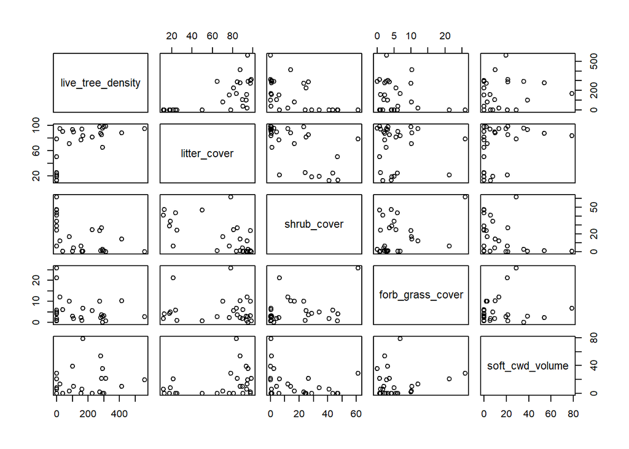

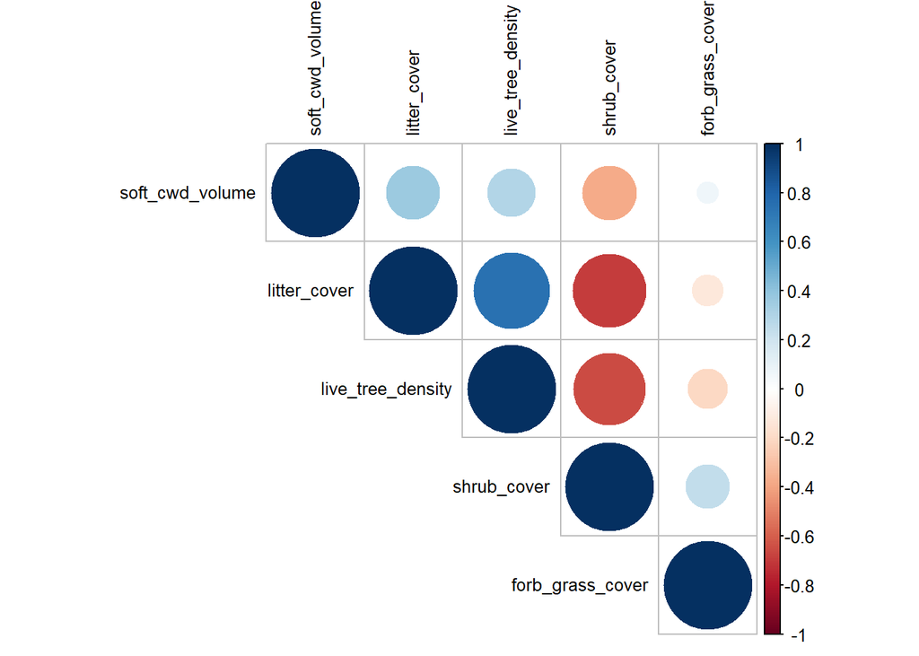

```
##            variable1         variable2 cor_strength
## 1  live_tree_density      litter_cover    0.7443395
## 2    soft_cwd_volume      litter_cover    0.3677445
## 3    soft_cwd_volume live_tree_density    0.2925383
## 4   forb_grass_cover       shrub_cover    0.2436641
## 5    soft_cwd_volume  forb_grass_cover    0.0604739
## 6       litter_cover  forb_grass_cover   -0.1276336
## 7  live_tree_density  forb_grass_cover   -0.2034880
## 8    soft_cwd_volume       shrub_cover   -0.3702504
## 9  live_tree_density       shrub_cover   -0.6566238
## 10      litter_cover       shrub_cover   -0.6910867
```

- Unsurprisingly, the three variables that changed with fire severity are highly correlated.

### PCA

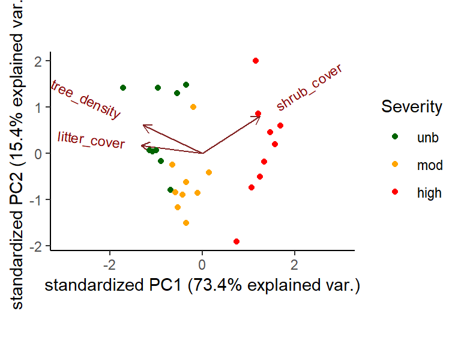

```
## Importance of components:
##                           PC1    PC2    PC3
## Standard deviation     1.4843 0.6796 0.5787
## Proportion of Variance 0.7344 0.1540 0.1116
## Cumulative Proportion  0.7344 0.8884 1.0000
```

### Figures

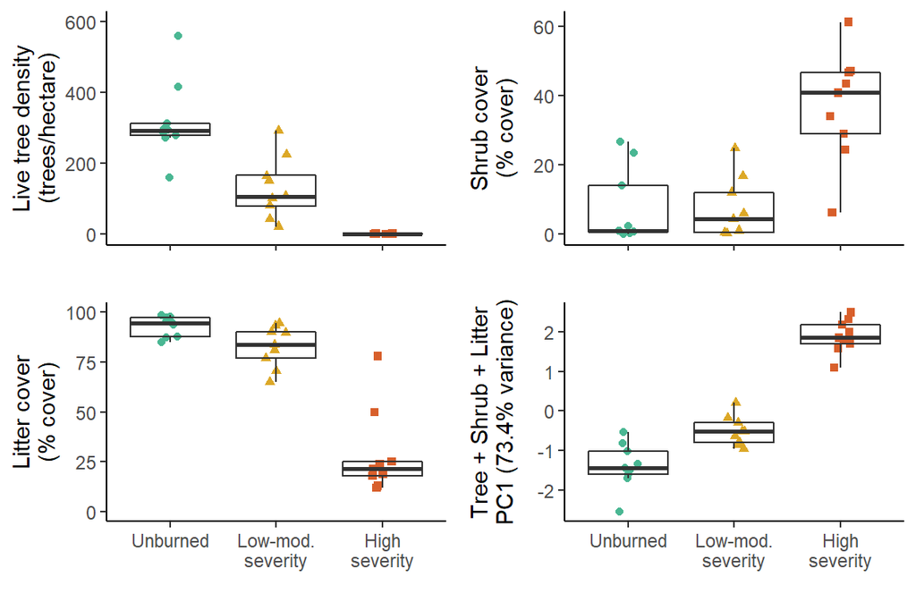

- **Figure 5a**
- Metrics that differed among fire severity categories, as well as PC1

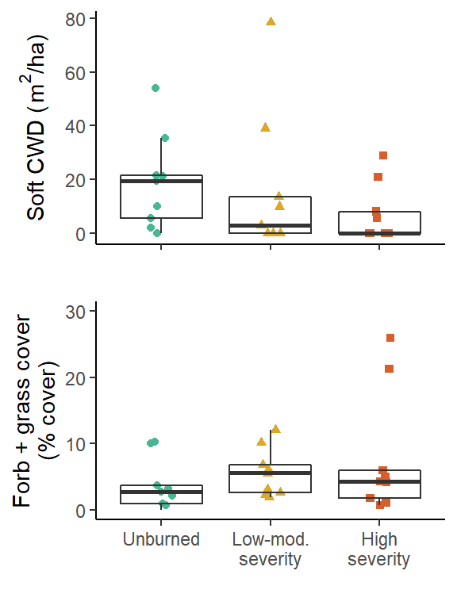

- **Figure 5b**
- Metrics that were similar among fire severity categories